# Team Part

## Question 1: What is the overall number of chocolate bars rated?

There are 1852 chocolate bars being rated. Code: length(choco$Rating).

```r
choco <- read.csv("https://xdaiisu.github.io/ds202materials/hwlabs/choco.csv")
length(choco$Rating)
```

```
## [1] 1852
```

## Question 2: How does the number of ratings depend on the year? Draw a bar chart of the number of reports.

The number of ratings have been going up since the dataset was created in 2006. However, in the year 2015, the ratings peaked and have been going back down since then.

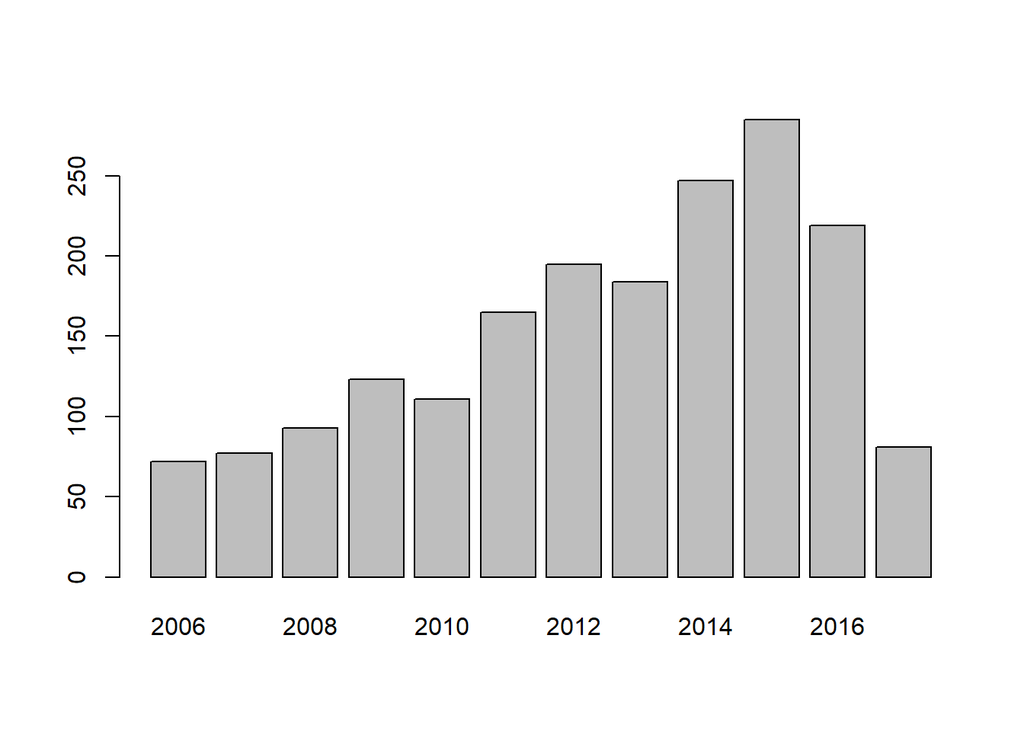

```r
barplot(table(choco$Review.Date))
```

## Question 3: Which are the three locations with the most ratings? How do ratings compare across these company locations?

```r
table(choco$Company.Location)
```

```
##
##         Amsterdam         Argentina         Australia           Austria
##                 6                 9                50                27
##           Belgium           Bolivia            Brazil            Canada
##                40                 2                18               132
##             Chile          Colombia        Costa Rica    Czech Republic
##                 2                23                 9                 1
##           Denmark Domincan Republic           Ecuador           Eucador
##                16                 5                55                 1
##              Fiji           Finland            France           Germany
##                 4                 2               158                36
##             Ghana           Grenada         Guatemala          Honduras
##                 1                 3                10                 6
##           Hungary           Iceland             India           Ireland
##                23                 3                 2                 4
##            Israel             Italy             Japan         Lithuania
##                 9                69                17                 6
##        Madagascar        Martinique            Mexico       Netherlands
##                17                 1                 4                 4
##       New Zealand         Niacragua         Nicaragua              Peru
##                17                 1                 5                17
##       Philippines            Poland          Portugal       Puerto Rico
##                 1                 8                 3                 4
##            Russia          Sao Tome          Scotland         Singapore
##                 3                 4                10                 3
##      South Africa       South Korea             Spain         St. Lucia
##                 3                 5                26                 2
##          Suriname            Sweden       Switzerland            U.A.E.
##                 1                 5                38                 4
##              U.K.            U.S.A.         Venezuela           Vietnam
##                98               787                20                11
##             Wales
##                 1
```

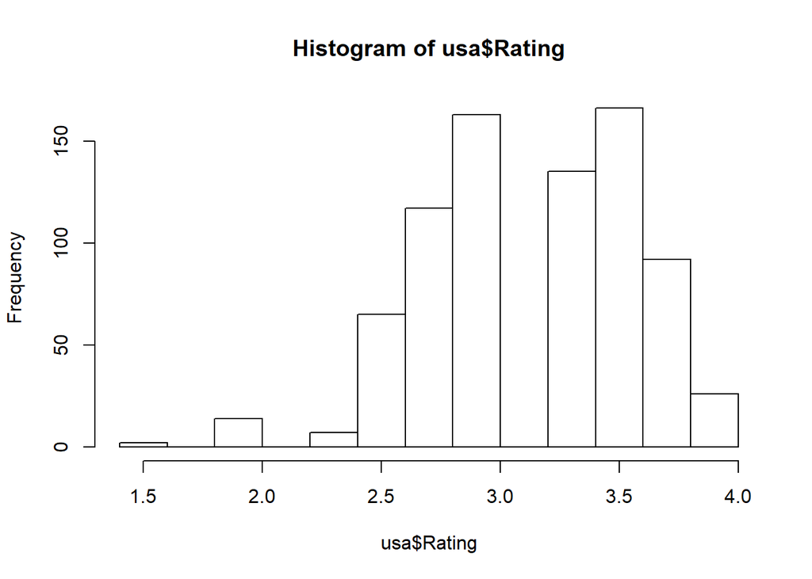

```r
usa <- choco[choco$Company.Location == 'U.S.A.',]
france <- choco[choco$Company.Location == 'France',]
canada <- choco[choco$Company.Location == 'Canada',]
hist(usa$Rating)
```

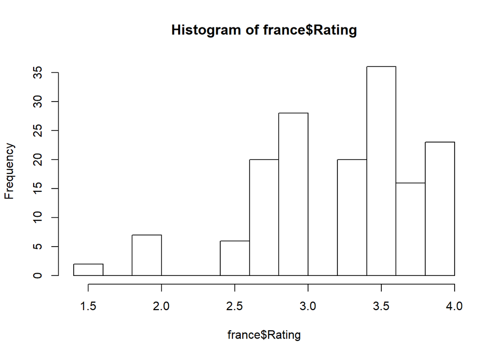

```r
hist(france$Rating)
```

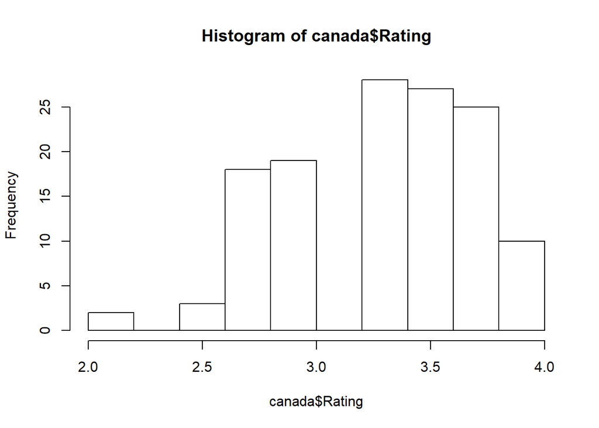

```r
hist(canada$Rating)
```

## Question 4: Brainstorm and write down an interesting question that can be answer from the dataset. The question should not duplicate the questions above.

What chocolate bar has the lowest percentage of cocoa? Did this have an impact on the rating as a result?

## Question 5: Answer the question from the dataset.

The lowest chocolate bar was from the Chokolat Elot (Girard) which is 42% cocoa. This definitely could of had an impact on the rating because it was rated at 2.75 which is on the lower half of all rated chocolate bars.

```r
choco[which.min(choco$Cocoa.Pct),]
```

```
##                    Company Specific.Bean.Origin  REF Review.Date Cocoa.Pct
## 439 Chokolat Elot (Girard)           Guadeloupe 1149        2013        42
##     Company.Location Rating Bean.Type Broad.Bean.Origin
## 439       Martinique   2.75                  Martinique
```

## Question 6: Write one paragraph commenting on the workflow.

In terms workflow, git hub was our biggest obstacle as neither of us had worked with it before and some of our files were saving in directories that were confusing to browse through. Once we got over all the github issues, which was about 3 hours of work time, everything else was pretty simple, except trying to make the plot for question 2, about one hour of cumulative time was spent there.  
Many of the solutions to these questions were solved from basic R functions. What’s unique about how we answered these questions was how we interpretted certain graphs and approached problems. There could have been more concise answers or solutions, however, we made our answers based on how it would be the best interpretted and followed by anyone. For instance, question 3 might have used more R code than other solutions but the approach is simple and can be easily followed and reciprocated.